# Analyzing pig movement across populations

Mark Wilber and Sarah Chinn

## The questions of the analysis

1. How do pigs select for anthropogenic forage resources and natural forage resources on the landscape?
2. How does the selection for anthropogenic forage resources and natural forage resources vary temporally? Can this be described by climatic variables such as snowdepth and temperature?
3. Do anthropogenic and natural forage resources interact to influence pig movement on a landscape? I.e. when both are present, does the availability of one affect the use of the other?

The goal of this analysis is **not** to build the best possible model of pig movement on a landscape. Rather, it is to understand how forage resources influence a resource selection in pigs whether this varies in a predictable way between populations.

To answer these questions, we are going to use the framework of continuous-time, discrete-space movement movels described in the previous summary I sent around. The analysis below is performed on 5 populations.

### Variable descriptions

The analyses below includes the following covariates. A cell is 30m by 30m.

1. *Correlated random walk* (`crw`): A gradient-response that determines the propensity of a pig to move in the direction that is was moving on it previous move. A positive coefficient indicates that a pig tends to move in the same direction as their previous step.
2. *Canopy cover* (`canopycover_loc` and `canopycover_grad`): The tree density of a given cell. `canopycover_loc` is a location-based covariates and a negative coeeficient indicates that as cell cover increases the rate at which a pig leaves that cell decreases (i.e. the time that the pig spends in that cell increases). `canopycover_grad` is a gradient-based covariate wand a positive coefficient indicates that pigs tend to move in the direction of a increasing canopy cover relative to their current position.
3. *Distance to water* (`water_loc` and `water_grad`): The distance a pig is from a perennial water source. `water_loc` is a location-based covariate where a positive coefficient indicates that pigs spend less time in cells that are further from water. `water_grad` is a gradient-based coefficient where a negative coefficient means that pigs tend to move closer to water.
4. *Distance to crops* (`crop_loc` and `crop_grad`): Distance to the neareast crop field. `crop_loc` is a location-based covariate where a positive coefficient indicates that pigs spend less time in cells that are further way from crop fields. `crop_grad` is a gradient-based covariate where a negative coefficient means that pigs tend to move closer to crop fields.
5. *Masting tree density* (`masting_loc` and `masting_grad`): The density of masting trees in a cell. `masting_loc` is a location-based covariate where a negative coefficient indicates that a pig spends more time in a cell with higher masting tree density. `masting_grad` is a gradient-based covariate where a positive value indicates that pigs move in the direction of higher masting tree density, relative to where they currently are.
6. *NDVI* (`ndvi_loc` and `ndvi_grad`): A proxy for plant productivity/natural plant forage not a accounted for by masting trees. Varies on a monthly scale. `ndvi_loc` is a location-based covariate where a negative coefficient indicates that pigs spend more time in cells with higher NDVI. `ndvi_grad` is a gradient-based covariate where a positive coefficient means that pigs tend to move in the direction of increasing NDVI, relative to where they currently are.
7. *Temperature* (`temperature_loc`): Mean monthly temperature varying by month. Interacts with precipitation, cover, water, and forage covariates.
8. *Precipitation* (`precipitation_loc`): Total monthly precipitation. Interacts with temperature, cover, water, and forage covariates.
9. *Snow depth* (`snowdepth_loc` and `snowdepth_grad`): Monthly variation in snowdepth at a 1km by 1km scale. `snowdepth_loc` is a location-based covariate where a positive coeffecient indicates that pigs spend less time in cells with higher snow depth. `snowdepth_grad` is a gradient-based coefficient where a negative value indicates that pigs tend to move away from increasing snowdepth, relative to their current location.

Of these variables *NDVI*, *Temperature*, *Precipication*, and *Snow depth* vary monthly, *Distance to crops* can vary yearly, and *Masting tree density*, *Canopy cover*, and *distance to water* are fixed.

## Data summary

Here are some brief summary plots of the populations that are being analyzed. One plot looks at median location of pigs in space and the other gives the break down between male and female pigs in a study.

```r
library(data.table)
library(glmnet)
library(foreach)
library(ggplot2)
require(doMC)
```

```r
tejondat = fread("/Users/mqwilber/Repos/rsf_swine/results/glmdata_by_study/tejon.csv")
```

```
Read 0.0% of 785272 rows
Read 28.0% of 785272 rows
Read 61.1% of 785272 rows
Read 94.2% of 785272 rows
Read 785272 rows and 53 (of 53) columns from 0.464 GB file in 00:00:06
```

```r
txdat = fread("/Users/mqwilber/Repos/rsf_swine/results/glmdata_by_study/txcamp.csv")
```

[output not shown]

```r
fldat = fread("/Users/mqwilber/Repos/rsf_swine/results/glmdata_by_study/fl_raoul.csv")
txtylerdat = fread("/Users/mqwilber/Repos/rsf_swine/results/glmdata_by_study/tx_tyler_w2.csv")
srelcdat = fread("/Users/mqwilber/Repos/rsf_swine/results/glmdata_by_study/srel_contact.csv")
```

```
Read 1.1% of 941760 rows
Read 28.7% of 941760 rows
Read 51.0% of 941760 rows
Read 77.5% of 941760 rows
Read 941760 rows and 53 (of 53) columns from 0.588 GB file in 00:00:06
```

```r
# Add in sex data
pigattrib = fread("~/Repos/rsf_swine/data/formatted/pig_attributes.csv")[, list(pigID, sex)]
# Check NA values, should have some in the crop values
tejondat[, lapply(.SD, function(x) any(is.na(x)))][1,] == FALSE
```

```
     DSCI imputeID  crw x.current y.current x.adj y.adj  tau    t datetime    z pigID temperature_loc precipitation_loc ndvi_loc beverage_and_spice_loc cereals_loc
[1,] TRUE     TRUE TRUE      TRUE      TRUE  TRUE  TRUE TRUE TRUE     TRUE TRUE  TRUE            TRUE              TRUE     TRUE                  FALSE        TRUE
     oilseed_loc other_loc fruit_and_nuts_loc grasses_loc leguminous_loc root_and_tuber_loc sugar_loc tobacco_loc vegetables_and_melons_loc crop_loc
[1,]       FALSE     FALSE               TRUE        TRUE          FALSE              FALSE     FALSE       FALSE                      TRUE     TRUE
     canopycover_loc developed_loc masting_loc elevation_loc water_loc snowdepth_loc ndvi_grad canopycover_grad developed_grad masting_grad beverage_and_spice_grad
[1,]            TRUE          TRUE        TRUE          TRUE      TRUE          TRUE      TRUE             TRUE           TRUE         TRUE                    TRUE
     cereals_grad oilseed_grad other_grad fruit_and_nuts_grad grasses_grad leguminous_grad root_and_tuber_grad sugar_grad tobacco_grad vegetables_and_melons_grad
[1,]         TRUE         TRUE       TRUE                TRUE         TRUE            TRUE                TRUE       TRUE         TRUE                       TRUE
     crop_grad elevation_grad water_grad snowdepth_grad study
[1,]      TRUE           TRUE       TRUE           TRUE  TRUE
```

```r
txdat[, lapply(.SD, function(x) any(is.na(x)))][1, ] == FALSE
```

```
     DSCI imputeID  crw x.current y.current x.adj y.adj  tau    t datetime    z pigID temperature_loc precipitation_loc ndvi_loc beverage_and_spice_loc cereals_loc
[1,] TRUE     TRUE TRUE      TRUE      TRUE  TRUE  TRUE TRUE TRUE     TRUE TRUE  TRUE            TRUE              TRUE     TRUE                  FALSE        TRUE
     oilseed_loc other_loc fruit_and_nuts_loc grasses_loc leguminous_loc root_and_tuber_loc sugar_loc tobacco_loc vegetables_and_melons_loc crop_loc
[1,]        TRUE      TRUE               TRUE        TRUE          FALSE              FALSE     FALSE       FALSE                     FALSE     TRUE
     canopycover_loc developed_loc masting_loc elevation_loc water_loc snowdepth_loc ndvi_grad canopycover_grad developed_grad masting_grad beverage_and_spice_grad
[1,]            TRUE          TRUE        TRUE          TRUE      TRUE          TRUE      TRUE             TRUE           TRUE         TRUE                    TRUE
     cereals_grad oilseed_grad other_grad fruit_and_nuts_grad grasses_grad leguminous_grad root_and_tuber_grad sugar_grad tobacco_grad vegetables_and_melons_grad
[1,]         TRUE         TRUE       TRUE                TRUE         TRUE            TRUE                TRUE       TRUE         TRUE                       TRUE
     crop_grad elevation_grad water_grad snowdepth_grad study
[1,]      TRUE           TRUE       TRUE           TRUE  TRUE
```

```r
# Merge the pig attributes to the data
tejondat = merge(tejondat, pigattrib, by="pigID")[!is.na(ndvi_loc)]
txdat = merge(txdat, pigattrib, by="pigID")[!is.na(ndvi_loc)]
fldat = merge(fldat, pigattrib, by="pigID")[!is.na(ndvi_loc)]
txtylerdat = merge(txtylerdat, pigattrib, by="pigID")[!is.na(ndvi_loc)]
srelcdat = merge(srelcdat, pigattrib, by="pigID")[!is.na(ndvi_loc)]
```

```r
pig1 = tejondat[pigID == "tejonM302"]
res = build_design_matrix(pig1, c("crop"), modeltype="main_effects")
pig1 = res$data
evalform = res$evalform
evalform = update.formula(evalform, .~ . - sex)
Xmat = model.matrix(evalform, data=pig1)
allXs[[studynm]] = Xmat
registerDoMC(cores=4)
# Fit overall model with GLM LASSO
fit_model1 = cv.glmnet(Xmat, y=dat$z, offset=log(dat$tau), family="poisson",
                       alpha=1, nlambda=20, nfolds=4, parallel=TRUE)
```

```
Error in glmnet(x, y, weights = weights, offset = offset, lambda = lambda,  :
  number of observations in y (941760) not equal to the number of rows of x (182776)
```

```r
fit_model1$glmnet.fit$beta[, 10, drop=F]
```

```
12 x 1 sparse Matrix of class "dgCMatrix"
                            s9
(Intercept)         .
crw_z               0.96550110
canopycover_loc_z  -0.84286634
canopycover_grad_z  0.04484230
water_loc_z         0.01446564
water_grad_z       -0.03339660
ndvi_loc_z         -0.18055208
ndvi_grad_z         .
masting_loc_z       0.20765190
masting_grad_z     -0.01201165
crop_loc_z         -0.06341301
crop_grad_z         0.00738458
```

```r
source("pigfxns.R")
dataset = list(txcamp=txdat, tejon=tejondat, fl_raoul=fldat, tx_tyler_w2=txtylerdat, srel_contact=srelcdat)
```

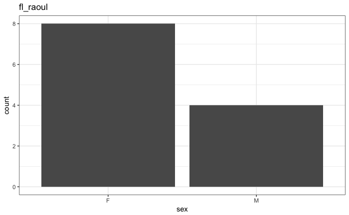

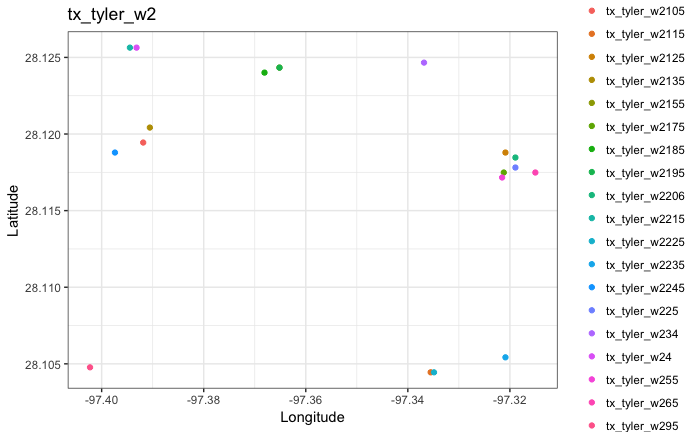

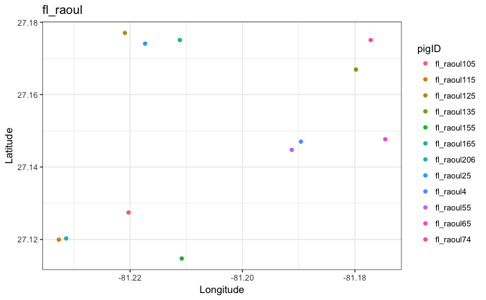

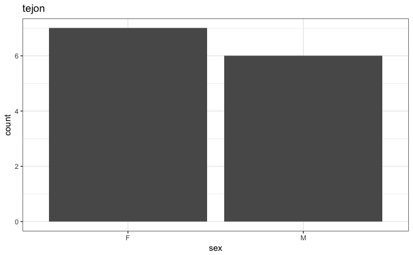

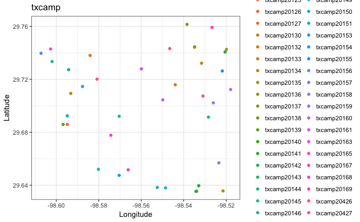

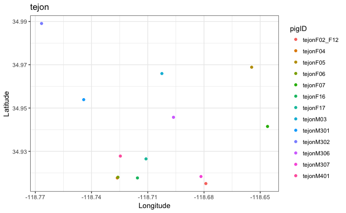

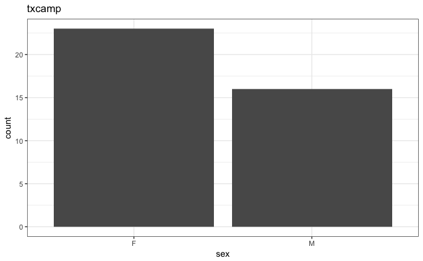

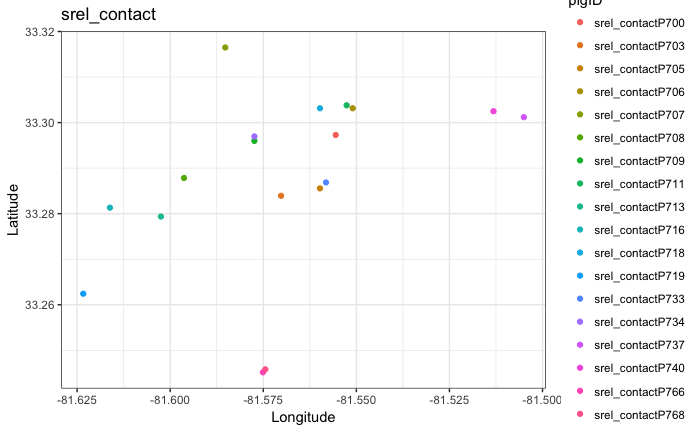

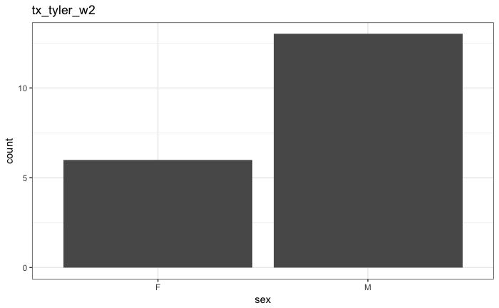

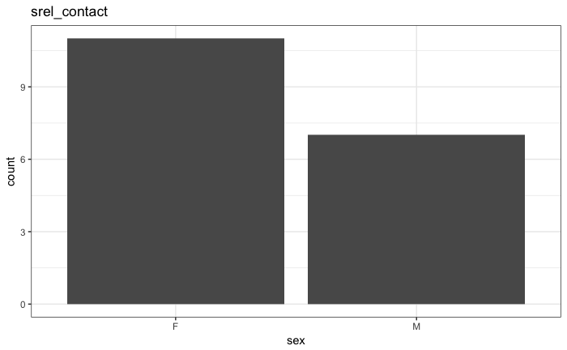

```r
for(studynm in names(dataset)){
  dat = dataset[[studynm]]
  meandat = dat[, list(meanlat=median(y.adj), meanlon=median(x.adj), sex=unique(sex)[1]), by=pigID]
  plot1 = ggplot(meandat) + geom_point(aes(x=meanlon, y=meanlat, color=pigID)) + theme_bw() + xlab("Longitude") + ylab("Latitude") + ggtitle(studynm)
  plot2 = ggplot(meandat) + geom_bar(aes(x=sex)) + theme_bw() + ggtitle(studynm)
  print(plot1)
  print(plot2)
}
```

# Analyzing the influence of foraging resources on the movement patterns of pigs

A four step analysis. Each analysis is performed separately for each population.

**Goal**: How do anthropogenic (i.e. crops) and natural forage resources affect pig movement, how do these effects vary over time, and how do these effects vary with climatic variables such as temperature and precipitation?

### Model 1: Simple main effects model

This model is giving us a sense of overall patterns in how pigs are using foraging resources, cover, and water. Purposefully ignoring a lot of the inherent complexity in this first set of models.

Fit the GLM LASSO model to each dataset

```r
require(doMC)
allmodel1_fits = list()
allXs = list()
for(studynm in names(dataset)){

  cat("Fitting", studynm, "\n")
  dat = dataset[[studynm]]

  # Following Buderman et al. standardize on a per pig level, rather than across all pigs?
  res = build_design_matrix(dat, c("crop"), modeltype="main_effects")
  dat = res$data
  dataset[[studynm]] = res$data

  evalform = res$evalform

  Xmat = model.matrix(evalform, data=dat)
  allXs[[studynm]] = Xmat

  registerDoMC(cores=4)

  # Fit overall model with GLM LASSO
  fit_model1 = cv.glmnet(Xmat, y=dat$z, offset=log(dat$tau), family="poisson",
                       alpha=1, nlambda=20, nfolds=4, parallel=TRUE)
  allmodel1_fits[[studynm]] = fit_model1
}
```

```
Fitting txcamp
Fitting tejon
Fitting fl_raoul
Fitting tx_tyler_w2
Fitting srel_contact
```

Examine the results of the regularized model fit.

```r
mod1_betas = list()
for(studynm in names(allmodel1_fits)){
  tfit = allmodel1_fits[[studynm]]
  # plot(tfit)
  print(tfit$glmnet.fit$beta[, which(tfit$lambda == tfit$lambda.min), drop=F])
  mod1_betas[[studynm]] = tfit$glmnet.fit$beta[, which(tfit$lambda == tfit$lambda.1se), drop=T]
}
```

```
13 x 1 sparse Matrix of class "dgCMatrix"
                            s15
(Intercept)         .
crw_z               0.671702630
sexM                0.055732129
canopycover_loc_z  -0.156327704
canopycover_grad_z  0.047248459
water_loc_z         0.058030428
water_grad_z       -0.007325545
ndvi_loc_z          0.021886146
ndvi_grad_z         0.002813950
masting_loc_z      -0.018955330
masting_grad_z      0.014073827
crop_loc_z         -0.062845076
crop_grad_z        -0.002881847
13 x 1 sparse Matrix of class "dgCMatrix"
                            s14
(Intercept)         .
crw_z               0.702558640
sexM               -0.028677320
canopycover_loc_z  -0.318927807
canopycover_grad_z -0.002253872
water_loc_z        -0.237113936
water_grad_z       -0.006362242
ndvi_loc_z         -0.298537302
ndvi_grad_z        -0.008595413
masting_loc_z      -0.070171648
masting_grad_z     -0.006448511
crop_loc_z         -0.248102303
crop_grad_z         0.008779372
13 x 1 sparse Matrix of class "dgCMatrix"
                             s9
(Intercept)         .
crw_z               0.634633362
sexM                0.192283147
canopycover_loc_z  -0.208716163
canopycover_grad_z  0.007360970
water_loc_z         .
water_grad_z       -0.010756920
ndvi_loc_z          0.074534949
```

[output cut: 20 more lines]

```
13 x 1 sparse Matrix of class "dgCMatrix"
                             s13
(Intercept)         .
crw_z               0.6901901200
sexM                0.3808647739
canopycover_loc_z  -0.1973241351
canopycover_grad_z  0.0546441824
water_loc_z         0.1101005027
water_grad_z       -0.0170134897
ndvi_loc_z          0.0127651281
ndvi_grad_z         0.0035280909
masting_loc_z       0.1113606769
masting_grad_z      0.0002631984
crop_loc_z          0.1229700538
crop_grad_z         0.0004077507
```

Plot results by coefficient.

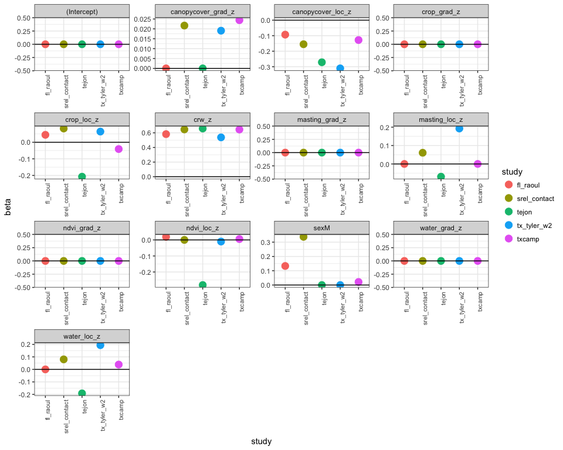

```r
tmpdt = list()
for(studynm in names(mod1_betas)){

  betas = mod1_betas[[studynm]]
  nms = names(betas)
  dt = data.table(coef=nms, beta=betas, study=studynm)
  tmpdt[[studynm]] = dt
}
mod1betas = do.call(rbind, tmpdt)
ggplot(mod1betas) + geom_point(aes(x=study, y=beta, color=study), size=4) + facet_wrap(~coef,  scales='free') +
              geom_hline(aes(yintercept=0)) + theme_bw() + theme(axis.text.x = element_text(angle = 90, hjust = 1, size=8))
```

**Summary for Model 1**

*Consistent effect*

1. `canopycover_loc`: For all studies, pigs tended to spend more time in higher cover habitat relative to lower cover habitat
2. `canopycover_grad`: For all studies, either showed no directional bias or tended to move toward higher cover habitat.
3. `crw`: All pigs tended to continue moving in the direction they were previously moving.

*Variable effects*

## Model 2: Time-varying analysis for studies

**Question:** What is the effect of time of day and season on the resource selection of pigs?

- Not including interactions between resources
- Not including monthly precipitation and tempurature variables as the montly time variation in resource use should (less mechanistically) account for this
- Explore daily and monthly changes in resource use. *Daily effects*: General movement *Monthly efects*: Canopy cover, forage resources, and distance to water. Note NDVI is already varying by month, so I am not sure it makes a ton of sense to model a time-varying coefficient for this variable. Doing it anyway for now.

```r
source("pigfxns.R")
df_hour = 6 # Number of basis vectors for the splines for hour
# Allow the monthly basis functions to vary between studies as they are of different lengths.
# If a study spans the course of a year, use a cyclic spline, otherwise use a cubic regression spline
cc_year = list(txcamp=list(FALSE, "cr", 4), tejon=list(TRUE, "cc", 4), fl_raoul=list(FALSE, "cr", 4), tx_tyler_w2=c(FALSE, "cr", 1), srel_contact=list(FALSE, "cr", 4))
allmodel2_fits = list()
allXgams = list()
for(studynm in names(dataset)){

  cat("Fitting", studynm, "\n")
  dat = dataset[[studynm]]

  # Extract hour of day and month of year for spline fitting
  dat[ , datetime:=as.POSIXct(t, origin = '1970-01-01', tz = 'GMT')]
  dat[ , hourofday:=hour(datetime)]
  dat[ , monthofyear:=month(datetime)]

  Xgam  = build_gam_design_matrix(allXs[[studynm]], dat, c("(Intercept)", "crw_z", "sexM"), df_hour=df_hour, df_month=cc_year[[studynm]][[3]], cyclic_year=cc_year[[studynm]][[1]])
  allXgams[[studynm]] = Xgam

  registerDoMC(cores=4)
  fitmodel2 = cv.glmnet(x=Xgam, y=dat$z, offset=log(dat$tau),
                        family="poisson", alpha=1, nlambda=20, nfolds=4, parallel=TRUE)
  allmodel2_fits[[studynm]] = fitmodel2
}
```

[output not shown]

Explore the nature of the time-varying effects after LASSO regularization. Extract the betas that minimize CV Deviance.

```r
gambetas = list()
for(studynm in names(allmodel2_fits)){

  tfit = allmodel2_fits[[studynm]]
  #plot(tfit)
  gambetas[[studynm]] = tfit$glmnet.fit$beta[, which(tfit$lambda == tfit$lambda.min), drop=T]
}
```

After regularization, how do these effects vary with time? Let’s look at the daily effect on movement rate first

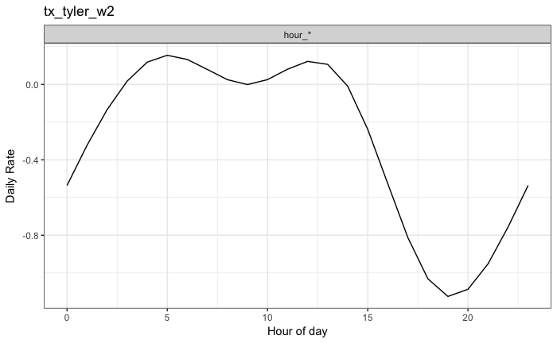

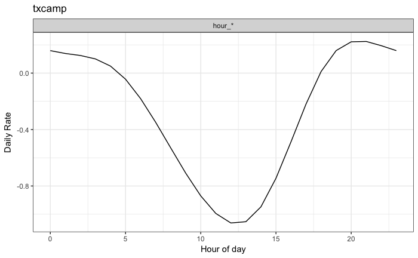

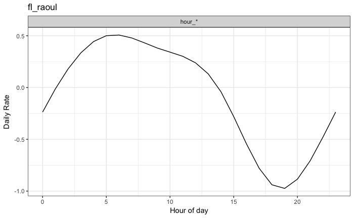

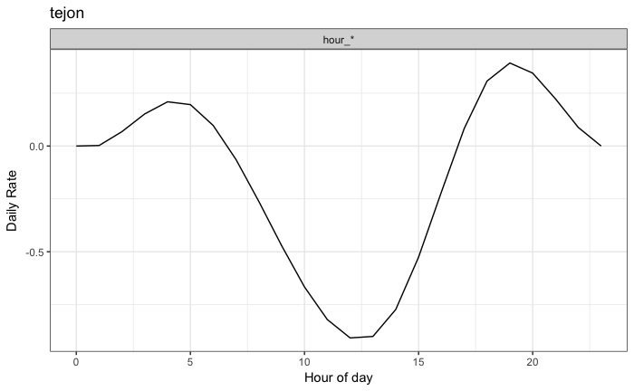

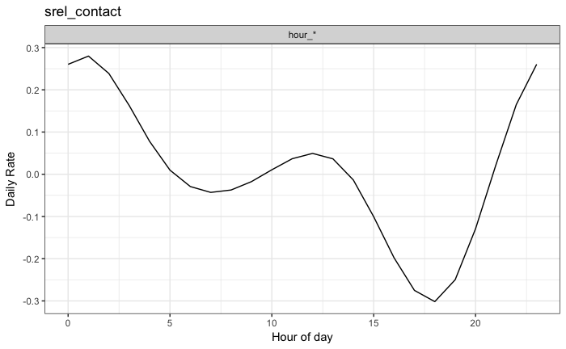

```r
library(ggplot2)
for(studynm in names(dataset)){

  dat = dataset[[studynm]]
  splinehour = s(hourofday, bs="cc", k=df_hour)
  pred_hours = Predict.matrix(smooth.construct2(splinehour, dat, NULL), data.frame(hourofday=0:23)) # B-spline basis for hour effect
  bestbetas = gambetas[[studynm]]

  dailyres = list()
  for(pattern in c("hour_*")){

    eff = pred_hours %*% t(t(bestbetas[names(bestbetas) %like% pattern]))
    effdt = data.frame(hour=0:23, beta=eff, coef=pattern)
    dailyres[[pattern]] = effdt
  }

  dailyres = do.call(rbind, dailyres)
  tplot = ggplot(dailyres) + geom_line(aes(x=hour, y=beta)) + xlab("Hour of day") + ylab("Daily Rate") + theme_bw() + facet_wrap(~coef) + ggtitle(studynm)
  print(tplot)

}
```

As expected, all pigs show reduced movement rates at some time of the day, but these effects are not consistent across pig populations. A few populations tend to show reduced movement later in the day, while others show reduced movement around midday.

Now let’s look at how our covariates vary with month.

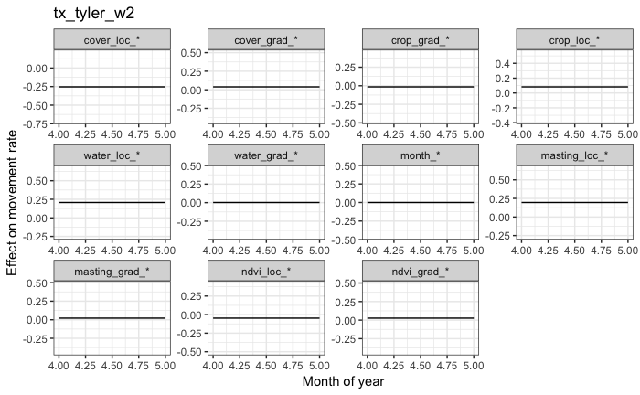

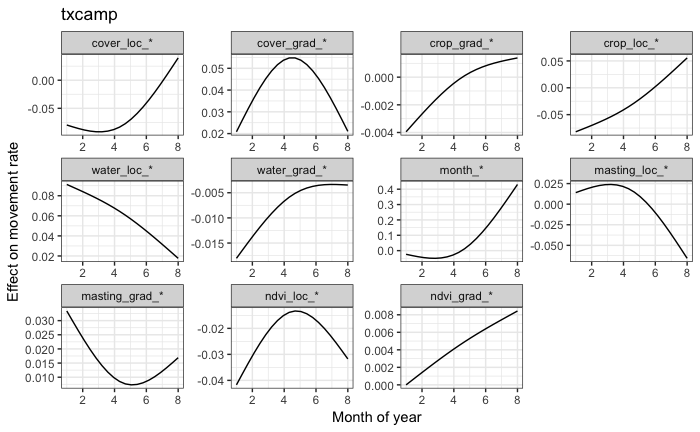

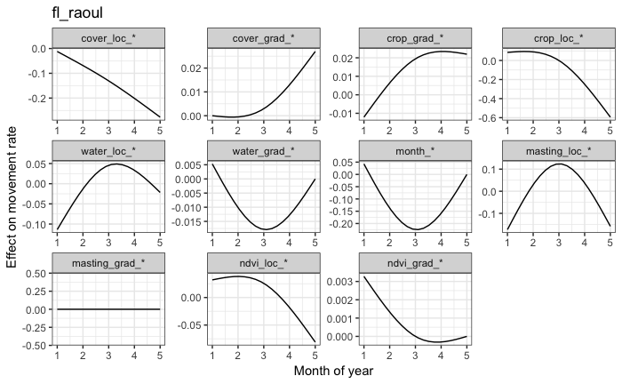

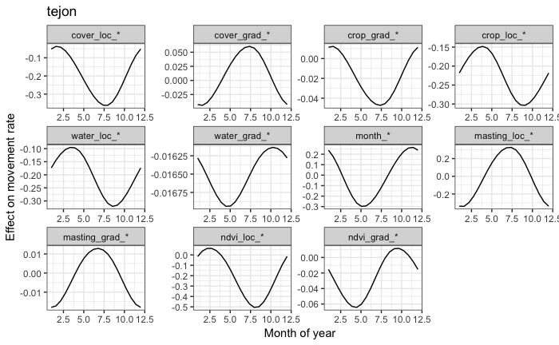

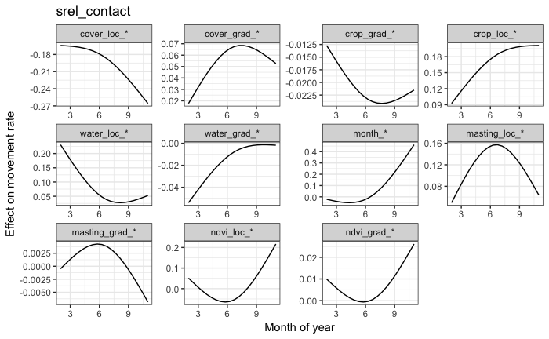

```r
allmonthres = list()
for(studynm in names(dataset)){

  dat = dataset[[studynm]]

  maxdfmonth = ifelse(cc_year[[studynm]][[3]] == 1, 2, cc_year[[studynm]][[3]])
  splinemonth = s(monthofyear, bs=cc_year[[studynm]][[2]], k=ifelse(cc_year[[studynm]][[1]], maxdfmonth, maxdfmonth  - 1))

  minmonth = min(dat$monthofyear)
  maxmonth = max(dat$monthofyear)

  if(cc_year[[studynm]][[3]] > 1)
    pred_months = Predict.matrix(smooth.construct2(splinemonth, dat, NULL), data.frame(monthofyear=seq(minmonth, maxmonth, len=20)))
  else
    pred_months = t(t(rep(1, 20)))
  bestbetas = gambetas[[studynm]]

  monthres = list()
  for(pattern in c("cover_loc_*", "cover_grad_*", "crop_grad_*", "crop_loc_*", "water_loc_*", "water_grad_*",
                 "month_*", "masting_loc_*", "masting_grad_*", "ndvi_loc_*", "ndvi_grad_*")){

    eff = pred_months %*% t(t(bestbetas[names(bestbetas) %like% pattern]))
    effdt = data.frame(month=seq(minmonth, maxmonth, len=20), beta=eff, coef=pattern)
    monthres[[pattern]] = effdt
  }

  monthres = do.call(rbind, monthres)
  monthres$study = studynm
  allmonthres[[studynm]] = monthres
  tplot = ggplot(monthres) + geom_line(aes(x=month, y=beta)) + xlab("Month of year") +
                  ylab("Effect on movement rate") + theme_bw() + facet_wrap(~coef, scales="free") + ggtitle(studynm)
  print(tplot)

}
```

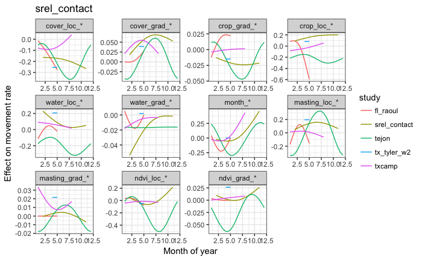

```r
allmonthres = do.call(rbind, allmonthres)
tplot = ggplot(allmonthres) + geom_line(aes(x=month, y=beta, color=study)) + xlab("Month of year") +
                  ylab("Effect on movement rate") + theme_bw() + facet_wrap(~coef, scales="free") + ggtitle(studynm)
print(tplot)
```

Some interesting population-specific effects

**Tejon**

1. The Tejon population shows strong seasonal variation in selection for resources
2. During the summer months there is a tendency to move toward crops and move faster once near crops.
3. This effect diminshes in the winter months in which there is a tendency to spend more time in cells with increased density of masting trees. In contrast, there is a tendency to spend less time in cells with high masting density in the summer.

**Camp Bullis**

1. Relatively weak seasonal effects of resource selection

**Florida, `fl_raoul`**

## Model 3: Interactive effects of resources on pig movement

In others words, given a pig is in or near a natural or agricultural resource, how does the presence of another resource (or distance to that resource) affect the time the pigs spends in the current resource.

For this analysis, we are going to keep the strong effects of hour and month on general movement patterns, but only consider interactions between static forage resources (i.e. the effects of resources are not time varying).

```r
source("pigfxns.R")
allmodel3_fits = list()
allXints = list()
for(studynm in names(dataset)){

  cat("Fitting", studynm, "\n")

  dat = dataset[[studynm]]
  inter = build_design_matrix(dat, c("crop"), modeltype = "interactions")
  dataset[[studynm]] = inter$data
  evalform = inter$evalform

  Xgam = allXgams[[studynm]]

  maxdfmonth = ifelse(cc_year[[studynm]][[3]] == 1, 2, cc_year[[studynm]][[3]])
  Xint = cbind(model.matrix(evalform, inter$data), Xgam[, c(paste0("hour_", 1:(df_hour - 1)), paste0("month_", 1:(maxdfmonth - 1)))])
  allXints[[studynm]] = Xint

  fitmodel3 = cv.glmnet(Xint, y=dat$z, offset=log(dat$tau),
                    family="poisson", alpha=1, nlambda=20, nfolds=4, parallel=TRUE)
  allmodel3_fits[[studynm]] = fitmodel3

}
```

```
Fitting txcamp
Fitting tejon
Fitting fl_raoul
Fitting tx_tyler_w2
Fitting srel_contact
```

```r
mod3betas = list()
for(studynm in names(allmodel3_fits)){

  tfit = allmodel3_fits[[studynm]]
  #plot(tfit)
  print(studynm)
  print(tfit$glmnet.fit$beta[, which(tfit$lambda == tfit$lambda.1se), drop=F])
  mod3betas[[studynm]] = tfit$glmnet.fit$beta[, which(tfit$lambda == tfit$lambda.min), drop=T]
}
```

```
[1] "txcamp"
25 x 1 sparse Matrix of class "dgCMatrix"
                                   s8
(Intercept)               .
crw_z                     0.654741513
sexM                      0.022073122
canopycover_loc_z        -0.038016717
canopycover_grad_z        0.028454627
water_loc_z               0.037203570
water_grad_z              .
ndvi_loc_z                0.008785920
ndvi_grad_z               .
masting_loc_z             .
masting_grad_z            .
crop_loc_z               -0.006457077
crop_grad_z               .
ndvi_loc_z:crop_loc_z     0.003819680
masting_loc_z:crop_loc_z  .
hour_1                    0.135220094
hour_2                    .
hour_3                   -0.729212057
hour_4                   -0.952687865
hour_5                    0.046747364
month_1                  -0.469413105
month_2                   .
month_3                  -0.078708201
month_4                   0.124639546
month_5                   0.321443780
[1] "tejon"
25 x 1 sparse Matrix of class "dgCMatrix"
                                  s7
(Intercept)               .
crw_z                     0.67574868
sexM                      .
canopycover_loc_z        -0.16555065
canopycover_grad_z        .
water_loc_z              -0.13548750
water_grad_z              .
ndvi_loc_z               -0.19433506
ndvi_grad_z               .
```

[output cut: 79 more lines]

```
masting_grad_z            .
crop_loc_z                0.14474090
crop_grad_z              -0.01532805
ndvi_loc_z:crop_loc_z     0.01317622
masting_loc_z:crop_loc_z -0.01211618
hour_1                    0.24647887
hour_2                    0.02020511
hour_3                    .
hour_4                    .
hour_5                   -0.27426166
month_1                  -0.20255781
month_2                   .
month_3                  -0.15755942
month_4                   0.16292087
month_5                   0.32195080
```

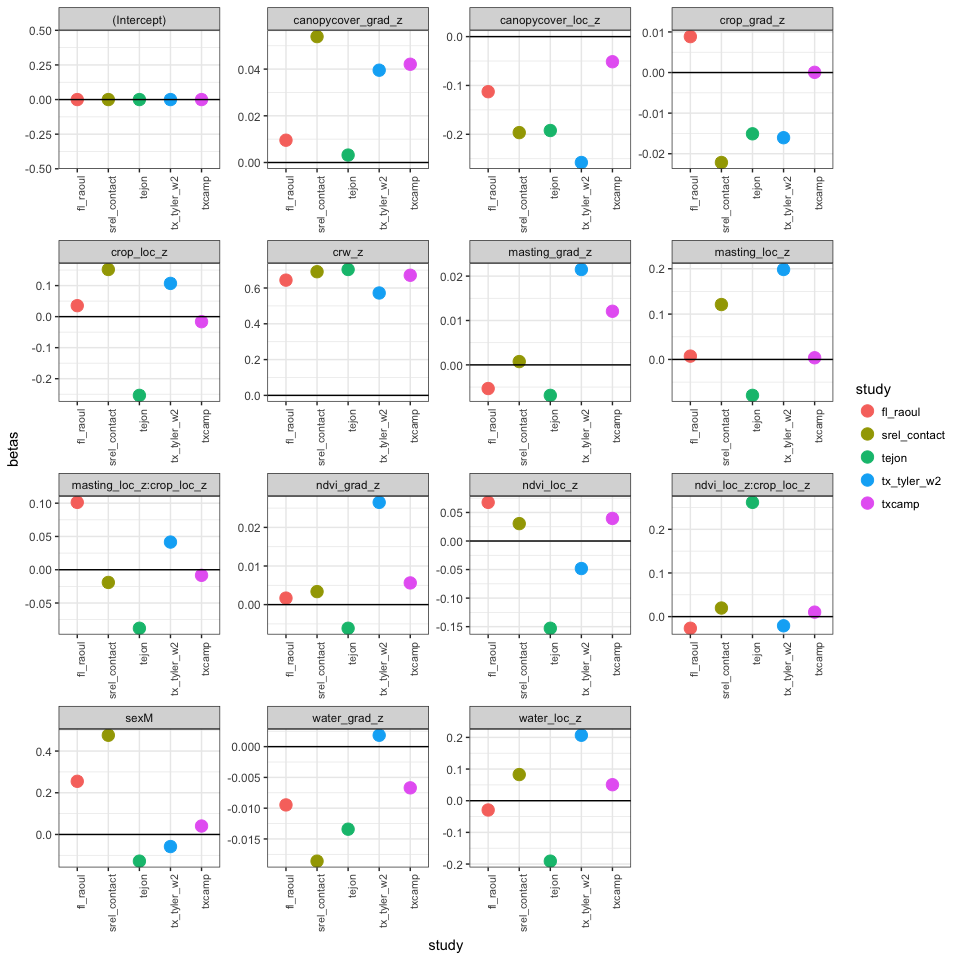

```r
tmpdt = list()
nm = 15
for(studynm in names(mod3betas)){

  betas = mod3betas[[studynm]][1:15]
  nms = names(betas)
  dt = data.table(coef=nms, betas, study=studynm)
  tmpdt[[studynm]] = dt
}
mod3betas_new = do.call(rbind, tmpdt)
ggplot(mod3betas_new) + geom_point(aes(x=study, y=betas, color=study), size=4) + facet_wrap(~coef,  scales='free') +
              geom_hline(aes(yintercept=0)) + theme_bw() + theme(axis.text.x = element_text(angle = 90, hjust = 1, size=8))
```

This will be similar to model 2, but instead of basis functions that vary by month (we will keep the daily basis function), we will replace these effect by interactions with temperature and precipitation.

```r
source("pigfxns.R")
allmodel4_fits = list()
allXints_full = list()
for(studynm in names(dataset)){

  cat("Fitting", studynm, "\n")

  dat = dataset[[studynm]]
  inter = build_design_matrix(dat, c("crop"), modeltype = "full")
  dataset[[studynm]] = inter$data
  evalform = inter$evalform

  Xgam = allXgams[[studynm]]
  Xint = cbind(model.matrix(evalform, inter$data), Xgam[, paste0("hour_", 1:(df_hour -1))])
  allXints_full[[studynm]] = Xint

  fitmodel4 = cv.glmnet(Xint, y=dat$z, offset=log(dat$tau),
                    family="poisson", alpha=1, nlambda=20, nfolds=4, parallel=TRUE)
  allmodel4_fits[[studynm]] = fitmodel4

}
```

```
Fitting txcamp
Fitting tejon
Fitting fl_raoul
Fitting tx_tyler_w2
Fitting srel_contact
```

```r
mod4betas = list()
for(studynm in names(allmodel4_fits)){

  tfit = allmodel4_fits[[studynm]]
  #plot(tfit)
  print(studynm)
  print(tfit$glmnet.fit$beta[, which(tfit$lambda == tfit$lambda.1se), drop=F])
  mod4betas[[studynm]] = tfit$glmnet.fit$beta[, which(tfit$lambda == tfit$lambda.1se), drop=T]
}
```

```
[1] "txcamp"
41 x 1 sparse Matrix of class "dgCMatrix"
                                                               s8
(Intercept)                                           .
crw_z                                                 0.654682427
sexM                                                  .
canopycover_loc_z                                    -0.056132072
canopycover_grad_z                                    0.028675983
ndvi_loc_z                                            0.019342303
ndvi_grad_z                                           .
masting_loc_z                                         .
masting_grad_z                                        .
water_grad_z                                          .
water_loc_z                                           0.043564029
crop_grad_z                                           .
crop_loc_z                                           -0.019318470
canopycover_loc_z:temperature_loc_z                   0.027619192
canopycover_grad_z:temperature_loc_z                  .
temperature_loc_z:ndvi_loc_z                         -0.023867673
ndvi_loc_z:precipitation_loc_z                       -0.052697726
temperature_loc_z:ndvi_grad_z                         .
ndvi_grad_z:precipitation_loc_z                       .
temperature_loc_z:masting_loc_z                      -0.020262993
precipitation_loc_z:masting_loc_z                     0.005669444
temperature_loc_z:masting_grad_z                      .
precipitation_loc_z:masting_grad_z                    .
temperature_loc_z:water_grad_z                        .
precipitation_loc_z:water_grad_z                      .
temperature_loc_z:water_loc_z                         .
precipitation_loc_z:water_loc_z                       .
temperature_loc_z:crop_loc_z                          0.024128431
precipitation_loc_z:crop_loc_z                        .
temperature_loc_z:ndvi_loc_z:precipitation_loc_z     -0.063758164
temperature_loc_z:ndvi_grad_z:precipitation_loc_z     .
temperature_loc_z:precipitation_loc_z:masting_loc_z   .
temperature_loc_z:precipitation_loc_z:masting_grad_z  .
temperature_loc_z:precipitation_loc_z:water_grad_z    .
temperature_loc_z:precipitation_loc_z:water_loc_z     0.029455114
temperature_loc_z:precipitation_loc_z:crop_loc_z      .
hour_1                                                0.127333136
```

[output cut: 165 more lines]

```
precipitation_loc_z:water_loc_z                      -0.0125165055
temperature_loc_z:crop_loc_z                          .
precipitation_loc_z:crop_loc_z                        0.0531119900
temperature_loc_z:ndvi_loc_z:precipitation_loc_z      .
temperature_loc_z:ndvi_grad_z:precipitation_loc_z     .
temperature_loc_z:precipitation_loc_z:masting_loc_z   .
temperature_loc_z:precipitation_loc_z:masting_grad_z  .
temperature_loc_z:precipitation_loc_z:water_grad_z    .
temperature_loc_z:precipitation_loc_z:water_loc_z     0.0211216172
temperature_loc_z:precipitation_loc_z:crop_loc_z      0.0284818579
hour_1                                                0.2308190823
hour_2                                                0.0072363992
hour_3                                                .
hour_4                                                .
hour_5                                               -0.2688890437
```

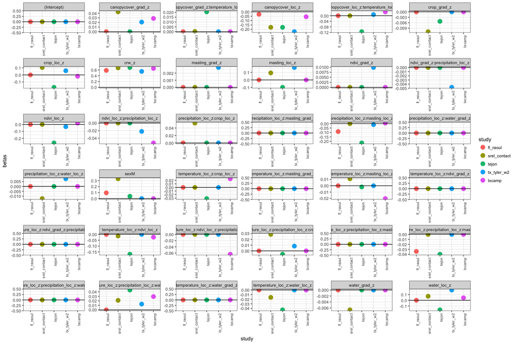

```r
tmpdt = list()
for(studynm in names(mod3betas)){

  betas = mod4betas[[studynm]][1:36]
  nms = names(betas)
  dt = data.table(coef=nms, betas, study=studynm)
  tmpdt[[studynm]] = dt
}
mod4betas_new = do.call(rbind, tmpdt)
ggplot(mod4betas_new) + geom_point(aes(x=study, y=betas, color=study), size=4) + facet_wrap(~coef,  scales='free') +
              geom_hline(aes(yintercept=0)) + theme_bw() + theme(axis.text.x = element_text(angle = 90, hjust = 1, size=8))
```

Plot the temperature, precipitation, and NDVI effects over “month of year”

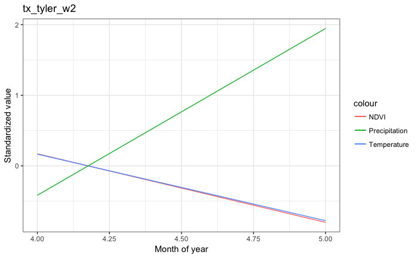

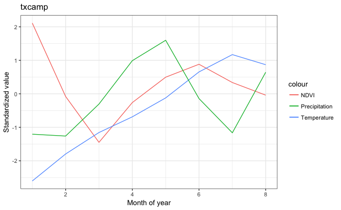

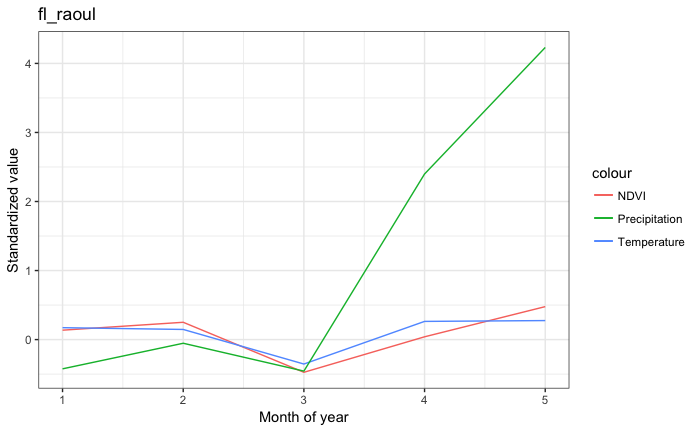

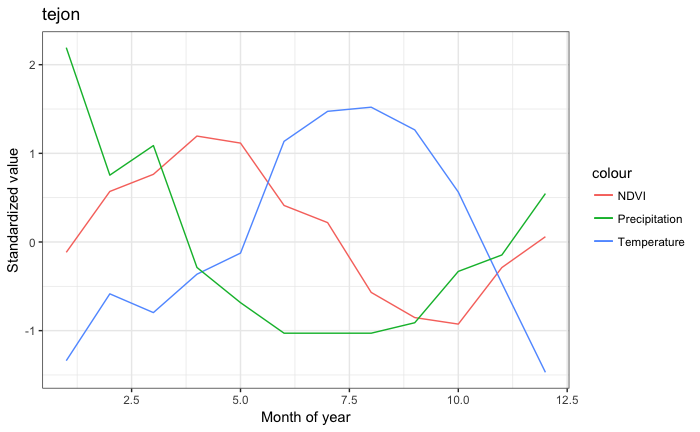

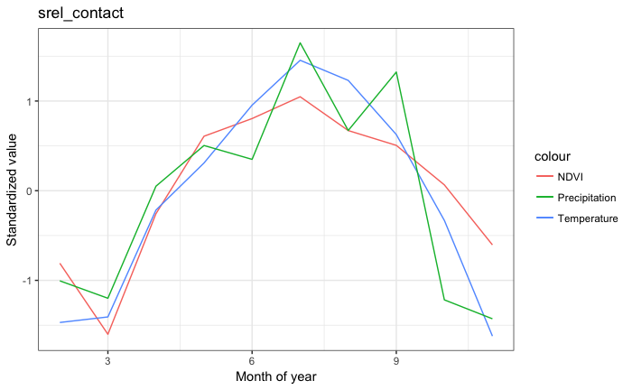

```r
for(studynm in names(dataset)){

  dat = dataset[[studynm]]
  meanvals = dat[, list(meantemp=mean(temperature_loc_z), meanprecip=mean(precipitation_loc_z), meanndvi=mean(ndvi_loc_z)), by=monthofyear]
  tplot = ggplot(meanvals) + geom_line(aes(x=monthofyear, y=meanndvi, color="NDVI")) + geom_line(aes(x=monthofyear, y=meantemp, color="Temperature")) +
                        geom_line(aes(x=monthofyear, y=meanprecip, color="Precipitation")) + theme_bw() + ylab("Standardized value") + xlab("Month of year") +
                        ggtitle(studynm)
  print(tplot)
}
```

There is less spatial variability in “natural” forage resources in Camp Bullis than in Tejon, which could diminish the effect on movement. Could be an interesting population-level predictor to consider for why the the role of natural vs crop resources on pig movement varies between population. The hypothesis is that with more homogeneous resource distributions (at what scale?), there is less signature of resource selection as pigs can wander more freely without worrying about getting to or staying in a particular resource patch. In general, the effects of all resources seem to be less in Camp Bullis, and I would suspect that has to do with the generally availability of resource (water and forage), though it would be nice to confirm this. If each chosen cell is “as good as” the next, then resource selection should have little effect on pig movement and movement should be dominated by a random walk or other biological factors (escape from predation?). This can also be a function of scale, where increasing spatial resolution can increase homogeneity and decrease the signature of foraging resource selection.

## Post-hoc population-level analyses

```r
sumdats = list()
for(studynm in names(dataset)){

  dat = dataset[[studynm]]
  sumdat = dat[z == 1, lapply(list(ndvi=ndvi_loc, crop=crop_loc, masting=masting_loc, water=water_loc, dev=developed_loc), function(x) quantile(x, c(0.5)))]
  sumdat$study = studynm
  sumdats[[studynm]] = sumdat

}
sumdatsdt = do.call(rbind, sumdats)
```

```r
-cos(2)
```

```
[1] 0.4161468
```